# Team 8: Credit Chronicles

Members: Sai Krishna ,Gourab Mukherjee, Tulasi

# **LOADING DATASET & CHECKING str():**

```r
library(readr)
credit_card <- read.csv("credit_card.csv")
print(str(credit_card))
```

```
## 'data.frame':    10127 obs. of  23 variables:
##  $ CLIENTNUM                                                                                                                         : int  768805383 818770008 713982108 769911858 709106358 713061558 810347208 818906208 710930508 719661558 ...
##  $ Attrition_Flag                                                                                                                    : chr  "Existing Customer" "Existing Customer" "Existing Customer" "Existing Customer" ...
##  $ Customer_Age                                                                                                                      : int  45 49 51 40 40 44 51 32 37 48 ...
##  $ Gender                                                                                                                            : chr  "M" "F" "M" "F" ...
##  $ Dependent_count                                                                                                                   : int  3 5 3 4 3 2 4 0 3 2 ...
##  $ Education_Level                                                                                                                   : chr  "High School" "Graduate" "Graduate" "High School" ...
##  $ Marital_Status                                                                                                                    : chr  "Married" "Single" "Married" "Unknown" ...
##  $ Income_Category                                                                                                                   : chr  "$60K - $80K" "Less than $40K" "$80K - $120K" "Less than $40K" ...
##  $ Card_Category                                                                                                                     : chr  "Blue" "Blue" "Blue" "Blue" ...
##  $ Months_on_book                                                                                                                    : int  39 44 36 34 21 36 46 27 36 36 ...
##  $ Total_Relationship_Count                                                                                                          : int  5 6 4 3 5 3 6 2 5 6 ...
##  $ Months_Inactive_12_mon                                                                                                            : int  1 1 1 4 1 1 1 2 2 3 ...
##  $ Contacts_Count_12_mon                                                                                                             : int  3 2 0 1 0 2 3 2 0 3 ...
##  $ Credit_Limit                                                                                                                      : num  12691 8256 3418 3313 4716 ...
##  $ Total_Revolving_Bal                                                                                                               : int  777 864 0 2517 0 1247 2264 1396 2517 1677 ...
##  $ Avg_Open_To_Buy                                                                                                                   : num  11914 7392 3418 796 4716 ...
##  $ Total_Amt_Chng_Q4_Q1                                                                                                              : num  1.33 1.54 2.59 1.4 2.17 ...
##  $ Total_Trans_Amt                                                                                                                   : int  1144 1291 1887 1171 816 1088 1330 1538 1350 1441 ...
##  $ Total_Trans_Ct                                                                                                                    : int  42 33 20 20 28 24 31 36 24 32 ...
##  $ Total_Ct_Chng_Q4_Q1                                                                                                               : num  1.62 3.71 2.33 2.33 2.5 ...
##  $ Avg_Utilization_Ratio                                                                                                             : num  0.061 0.105 0 0.76 0 0.311 0.066 0.048 0.113 0.144 ...
##  $ Naive_Bayes_Classifier_Attrition_Flag_Card_Category_Contacts_Count_12_mon_Dependent_count_Education_Level_Months_Inactive_12_mon_1: num  9.34e-05 5.69e-05 2.11e-05 1.34e-04 2.17e-05 ...
##  $ Naive_Bayes_Classifier_Attrition_Flag_Card_Category_Contacts_Count_12_mon_Dependent_count_Education_Level_Months_Inactive_12_mon_2: num  1 1 1 1 1 ...
## NULL
```

# **DIMENSIONS OF DATA:**

```r
dim(credit_card)
```

```
## [1] 10127    23
```

# **SUMMARY OF DATASET:**

```r
summary(credit_card)
```

```
##    CLIENTNUM        Attrition_Flag      Customer_Age     Gender
##  Min.   :7.08e+08   Length:10127       Min.   :26.0   Length:10127
##  1st Qu.:7.13e+08   Class :character   1st Qu.:41.0   Class :character
##  Median :7.18e+08   Mode  :character   Median :46.0   Mode  :character
##  Mean   :7.39e+08                      Mean   :46.3
##  3rd Qu.:7.73e+08                      3rd Qu.:52.0
##  Max.   :8.28e+08                      Max.   :73.0
##  Dependent_count Education_Level    Marital_Status     Income_Category
##  Min.   :0.00    Length:10127       Length:10127       Length:10127
##  1st Qu.:1.00    Class :character   Class :character   Class :character
##  Median :2.00    Mode  :character   Mode  :character   Mode  :character
##  Mean   :2.35
##  3rd Qu.:3.00
##  Max.   :5.00
##  Card_Category      Months_on_book Total_Relationship_Count
##  Length:10127       Min.   :13.0   Min.   :1.00
##  Class :character   1st Qu.:31.0   1st Qu.:3.00
##  Mode  :character   Median :36.0   Median :4.00
##                     Mean   :35.9   Mean   :3.81
##                     3rd Qu.:40.0   3rd Qu.:5.00
##                     Max.   :56.0   Max.   :6.00
##  Months_Inactive_12_mon Contacts_Count_12_mon  Credit_Limit
##  Min.   :0.00           Min.   :0.00          Min.   : 1438
##  1st Qu.:2.00           1st Qu.:2.00          1st Qu.: 2555
##  Median :2.00           Median :2.00          Median : 4549
##  Mean   :2.34           Mean   :2.46          Mean   : 8632
##  3rd Qu.:3.00           3rd Qu.:3.00          3rd Qu.:11068
##  Max.   :6.00           Max.   :6.00          Max.   :34516
##  Total_Revolving_Bal Avg_Open_To_Buy Total_Amt_Chng_Q4_Q1 Total_Trans_Amt
##  Min.   :   0        Min.   :    3   Min.   :0.00         Min.   :  510
##  1st Qu.: 359        1st Qu.: 1324   1st Qu.:0.63         1st Qu.: 2156
##  Median :1276        Median : 3474   Median :0.74         Median : 3899
##  Mean   :1163        Mean   : 7469   Mean   :0.76         Mean   : 4404
##  3rd Qu.:1784        3rd Qu.: 9859   3rd Qu.:0.86         3rd Qu.: 4741
##  Max.   :2517        Max.   :34516   Max.   :3.40         Max.   :18484
##  Total_Trans_Ct  Total_Ct_Chng_Q4_Q1 Avg_Utilization_Ratio
##  Min.   : 10.0   Min.   :0.00        Min.   :0.000
##  1st Qu.: 45.0   1st Qu.:0.58        1st Qu.:0.023
##  Median : 67.0   Median :0.70        Median :0.176
##  Mean   : 64.9   Mean   :0.71        Mean   :0.275
##  3rd Qu.: 81.0   3rd Qu.:0.82        3rd Qu.:0.503
##  Max.   :139.0   Max.   :3.71        Max.   :0.999
##  Naive_Bayes_Classifier_Attrition_Flag_Card_Category_Contacts_Count_12_mon_Dependent_count_Education_Level_Months_Inactive_12_mon_1
##  Min.   :0.00
##  1st Qu.:0.00
##  Median :0.00
##  Mean   :0.16
##  3rd Qu.:0.00
##  Max.   :1.00
##  Naive_Bayes_Classifier_Attrition_Flag_Card_Category_Contacts_Count_12_mon_Dependent_count_Education_Level_Months_Inactive_12_mon_2
##  Min.   :0.00
##  1st Qu.:1.00
##  Median :1.00
##  Mean   :0.84
##  3rd Qu.:1.00
##  Max.   :1.00
```

# **COLUMN NAMES IN THE DATASET:**

```r
column_names <- colnames(credit_card)
last_two_columns <- tail(column_names, 2)
print(column_names)
```

```
##  [1] "CLIENTNUM"
##  [2] "Attrition_Flag"
##  [3] "Customer_Age"
##  [4] "Gender"
##  [5] "Dependent_count"
##  [6] "Education_Level"
##  [7] "Marital_Status"
##  [8] "Income_Category"
##  [9] "Card_Category"
## [10] "Months_on_book"
## [11] "Total_Relationship_Count"
## [12] "Months_Inactive_12_mon"
## [13] "Contacts_Count_12_mon"
## [14] "Credit_Limit"
## [15] "Total_Revolving_Bal"
## [16] "Avg_Open_To_Buy"
## [17] "Total_Amt_Chng_Q4_Q1"
## [18] "Total_Trans_Amt"
## [19] "Total_Trans_Ct"
## [20] "Total_Ct_Chng_Q4_Q1"
## [21] "Avg_Utilization_Ratio"
## [22] "Naive_Bayes_Classifier_Attrition_Flag_Card_Category_Contacts_Count_12_mon_Dependent_count_Education_Level_Months_Inactive_12_mon_1"
## [23] "Naive_Bayes_Classifier_Attrition_Flag_Card_Category_Contacts_Count_12_mon_Dependent_count_Education_Level_Months_Inactive_12_mon_2"
```

# **AFTER DROPING UNNECESSARY COLUMNS:**

```r
credit_card_final <- subset(credit_card,select = !colnames(credit_card) %in% last_two_columns)
print(colnames(credit_card_final))
```

```
##  [1] "CLIENTNUM"                "Attrition_Flag"
##  [3] "Customer_Age"             "Gender"
##  [5] "Dependent_count"          "Education_Level"
##  [7] "Marital_Status"           "Income_Category"
##  [9] "Card_Category"            "Months_on_book"
## [11] "Total_Relationship_Count" "Months_Inactive_12_mon"
## [13] "Contacts_Count_12_mon"    "Credit_Limit"
## [15] "Total_Revolving_Bal"      "Avg_Open_To_Buy"
## [17] "Total_Amt_Chng_Q4_Q1"     "Total_Trans_Amt"
## [19] "Total_Trans_Ct"           "Total_Ct_Chng_Q4_Q1"
## [21] "Avg_Utilization_Ratio"
```

# **CHECKING FOR NULL VALUES**

```r
null_counts <- colSums(is.na(credit_card_final))
print(null_counts)
```

```
##                CLIENTNUM           Attrition_Flag             Customer_Age
##                        0                        0                        0
##                   Gender          Dependent_count          Education_Level
##                        0                        0                        0
##           Marital_Status          Income_Category            Card_Category
##                        0                        0                        0
##           Months_on_book Total_Relationship_Count   Months_Inactive_12_mon
##                        0                        0                        0
##    Contacts_Count_12_mon             Credit_Limit      Total_Revolving_Bal
##                        0                        0                        0
##          Avg_Open_To_Buy     Total_Amt_Chng_Q4_Q1          Total_Trans_Amt
##                        0                        0                        0
##           Total_Trans_Ct      Total_Ct_Chng_Q4_Q1    Avg_Utilization_Ratio
##                        0                        0                        0
```

# **REPLACING SPACES WITH NA AND CHECKING FOR NULL VALUES OR UNFILLED VALUES**

```r
credit_card_final[credit_card_final == " "] <- NA
null_counts1 <- colSums(is.na(credit_card_final))
print(null_counts1)
```

```
##                CLIENTNUM           Attrition_Flag             Customer_Age
##                        0                        0                        0
##                   Gender          Dependent_count          Education_Level
##                        0                        0                        0
##           Marital_Status          Income_Category            Card_Category
##                        0                        0                        0
##           Months_on_book Total_Relationship_Count   Months_Inactive_12_mon
##                        0                        0                        0
##    Contacts_Count_12_mon             Credit_Limit      Total_Revolving_Bal
##                        0                        0                        0
##          Avg_Open_To_Buy     Total_Amt_Chng_Q4_Q1          Total_Trans_Amt
##                        0                        0                        0
##           Total_Trans_Ct      Total_Ct_Chng_Q4_Q1    Avg_Utilization_Ratio
##                        0                        0                        0
```

# **EDA –> “Exploratory Data Analysis”**

# **EDA –> “Histograms - Utilized to gain an understanding of the distribution of continuous variables, providing insights into the central tendency, variability, and overall shape of the dataset’s distribution.Univariate Analysis - Examining individual variables in isolation.”**

[figure not shown]

```r
library(tidyverse)

character_columns <- credit_card_final%>% select_if(is.character)
#Analysis of all the numeric columns
numeric_columns <- names(credit_card_final %>%
  select_if(is.numeric) %>%
  select(-CLIENTNUM))



variable_columns <- c(numeric_columns)

col_names <- c(numeric_columns)

df <- credit_card_final %>%
  select(all_of(variable_columns)) %>%
  pivot_longer(cols = everything(), names_to = "Variable", values_to = "Value")

df$Variable <- factor(df$Variable, levels = variable_columns, labels = col_names)

p <- ggplot(df, aes(x = Value)) +
  geom_histogram(aes(y = ..count..), fill = '#66c2a5', color = '#004d40', bins = 30) +
  geom_freqpoly(color = "#e34a33", size = 1) +
  facet_wrap(~ Variable, scales = "free", ncol = 2) +
  theme_minimal() +
  labs(title = "Histograms of Numeric Variables", y = "Frequency") +
  theme(axis.text.x = element_text(angle = 45, hjust = 1))

options(
  repr.plot.width = 10,    # Adjust the width
  repr.plot.height = 6    # Adjust the height
)


print(p)
```

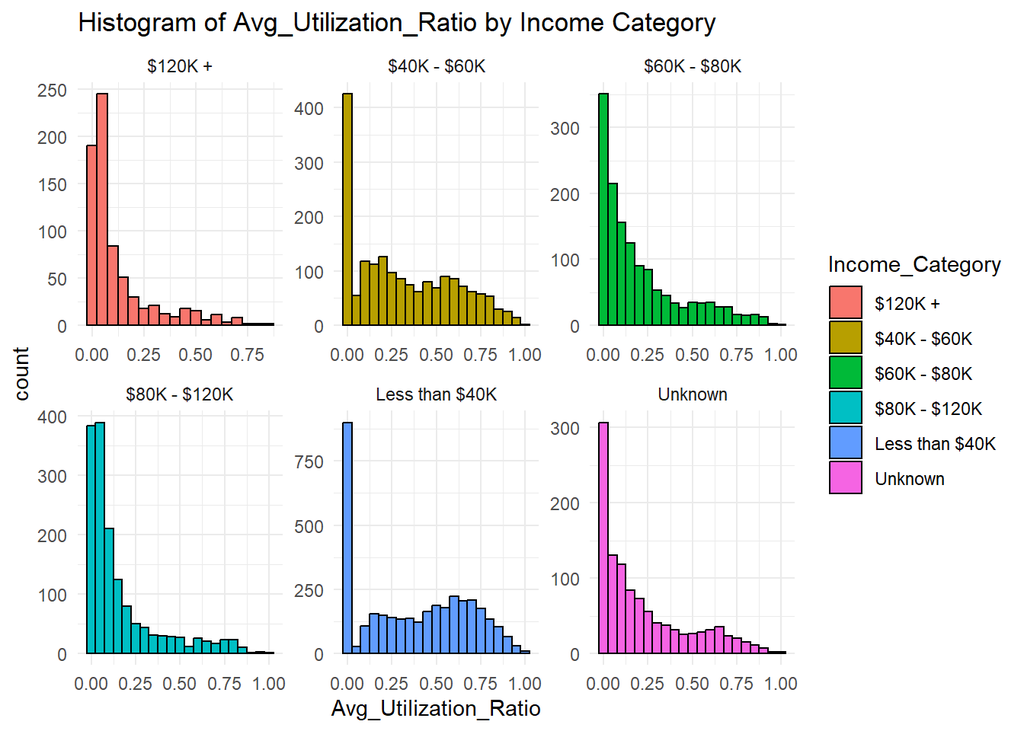

```r
library(dplyr)
library(ggplot2)
unknown <- "Uknown"
credit_card_final_without_unknown <- subset(credit_card_final, Income_Category!= unknown)
histogram_plot <- ggplot(credit_card_final_without_unknown, aes(x = Avg_Utilization_Ratio, fill = Income_Category)) +
  geom_histogram(binwidth = 0.05, color = "black") +
  facet_wrap(~Income_Category, scales = "free", ncol = 3) +
  labs(title = 'Histogram of Avg_Utilization_Ratio by Income Category') +
  theme_minimal()


print(histogram_plot)
```

```r
library(dplyr)
library(ggplot2)

# Grouping according to income category and calculating the aggregate of average utilization ratio of each income category in the dataframe
Income_category_and_average_utilization <- credit_card_final_without_unknown %>%
  group_by(Income_Category) %>%
  summarise(Avg_Utilization_Ratio = mean(Avg_Utilization_Ratio))

# Defining the order of the columns (lowest to highest)
cols <- c('Less than $40K', '$40K - $60K', '$60K - $80K', '$80K - $120K', '$120K +')


plot <- ggplot(Income_category_and_average_utilization, aes(x = Income_Category, y = Avg_Utilization_Ratio, fill = Income_Category)) +
  geom_bar(stat = "identity") +  # Use geom_bar for a bar plot
  scale_x_discrete(limits = cols) +
  labs(title = 'Average Card Utilization Ratio with respect to Income Category') +
  theme_minimal()

print(Income_category_and_average_utilization)
```

```
## # A tibble: 6 × 2
##   Income_Category Avg_Utilization_Ratio
##   <chr>                           <dbl>
## 1 $120K +                         0.125
## 2 $40K - $60K                     0.317
## 3 $60K - $80K                     0.206
## 4 $80K - $120K                    0.162
## 5 Less than $40K                  0.377
## 6 Unknown                         0.221
```

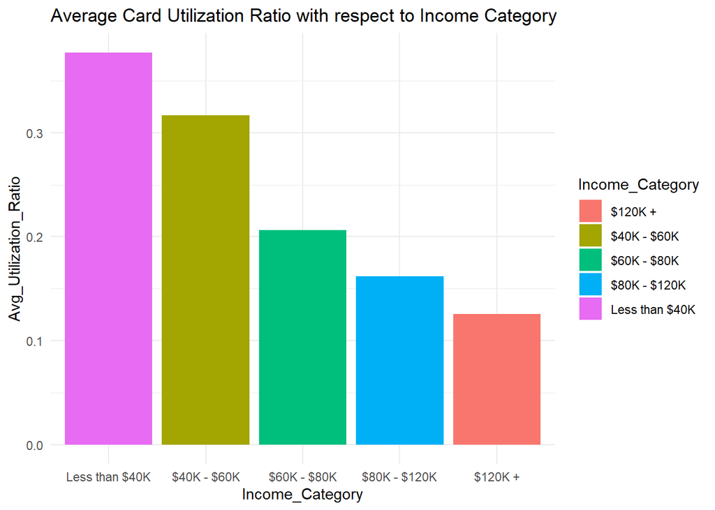

```r
# Display the plot
print(plot)
```

**The give bar plot implies that there is an inverse relationship between income range and credit card utilization, specifically, a decrease in credit card utilization as income range increases.** **In simpler terms, it means that people with higher income ranges tend to use a smaller proportion of their available credit on their credit cards compared to people with lower income ranges. This suggests that individuals with higher incomes may have more financial stability and may not need to rely as heavily on credit card debt, resulting in a lower credit card utilization ratio.**

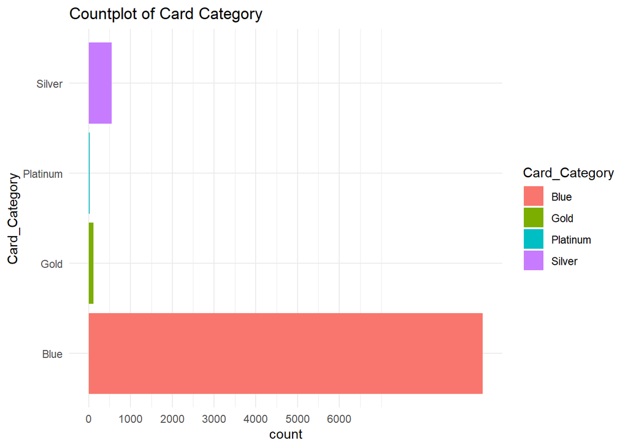

```r
library(dplyr)
library(ggplot2)

subset_data <- subset(credit_card_final_without_unknown, Credit_Limit!= unknown)


countplot <- ggplot(subset_data, aes(y = Card_Category, fill = Card_Category)) +
  geom_bar() +
  labs(title = "Countplot of Card Category ") +
    # Specify the color
  theme_minimal()+scale_x_continuous(breaks = seq(0,6000, by = 1000))

print(countplot)
```

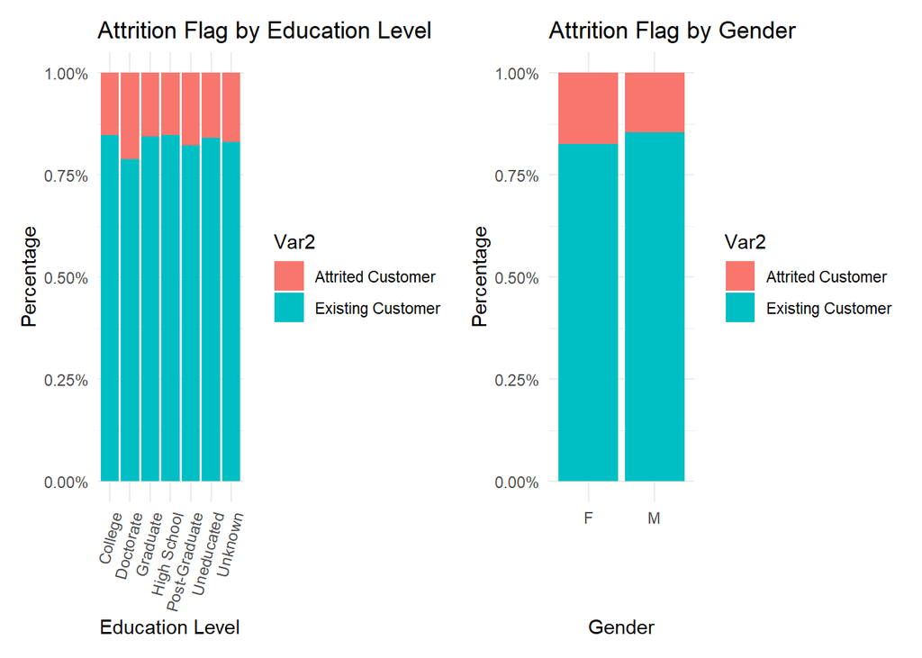

```r
library(ggplot2)
library(patchwork)
credit_card_final_without_unknown <- subset(credit_card_final_without_unknown, Education_Level!= unknown)

# Create a contingency table for Education Level
mar_bar_education <- table(credit_card_final_without_unknown$Education_Level, credit_card_final_without_unknown$Attrition_Flag)
mar_bar_education <- prop.table(mar_bar_education, margin = 1)

# Create a data frame for Education Level
mar_bar_education_df <- as.data.frame(mar_bar_education)
mar_bar_education_df$Education_Level <- rownames(mar_bar_education)

# Create a stacked bar plot for Education Level
plot_education <- ggplot(mar_bar_education_df, aes(x = Education_Level, y = Freq, fill = Var2)) +
  geom_bar(stat = "identity") +
  labs(title = "Attrition Flag by Education Level", x = "Education Level", y = "Percentage") +
  scale_y_continuous(labels = scales::percent_format(scale = 1)) +
  theme_minimal()+theme(axis.text.x = element_text(angle = 75, hjust = 1))

# Create a contingency table for Gender
mar_bar_gender <- table(credit_card_final_without_unknown$Gender, credit_card_final_without_unknown$Attrition_Flag)
mar_bar_gender <- prop.table(mar_bar_gender, margin = 1)

# Reorder levels to put "Attrition" below "Existing" for Gender
#mar_bar_gender <- mar_bar_gender[, c("Existing", "Attrited Customer")]

# Create a data frame for Gender
mar_bar_gender_df <- as.data.frame(mar_bar_gender)
mar_bar_gender_df$Gender <- rownames(mar_bar_gender)

# Create a stacked bar plot for Gender
plot_gender <- ggplot(mar_bar_gender_df, aes(x = Gender, y = Freq, fill = Var2)) +
  geom_bar(stat = "identity") +
  labs(title = "Attrition Flag by Gender", x = "Gender", y = "Percentage") +
  scale_y_continuous(labels = scales::percent_format(scale = 1)) +
  theme_minimal()

combined_plot <- plot_education + plot_gender +
  plot_layout(ncol = 2)

# Print the combined plot
print(combined_plot)
```

Boxplots offer a useful means of visualizing outliers in the dataset, aiding in the interpretation of data spread and skewness. They also provide information about central tendencies like the median and quartiles while highlighting potential data anomalies for each variable.

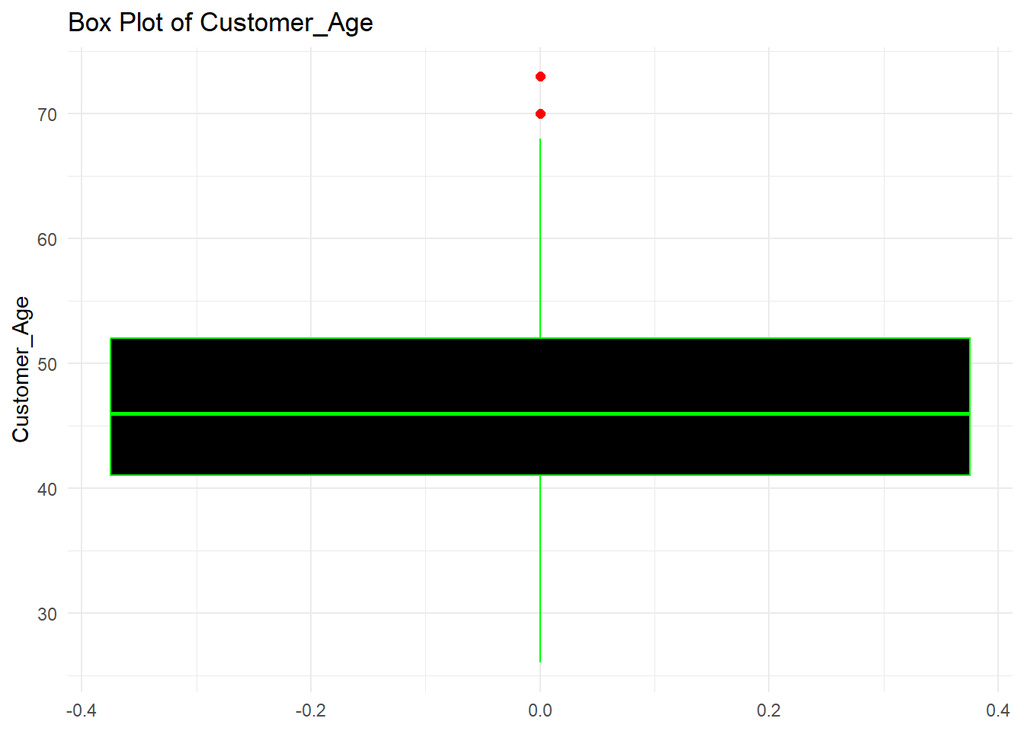

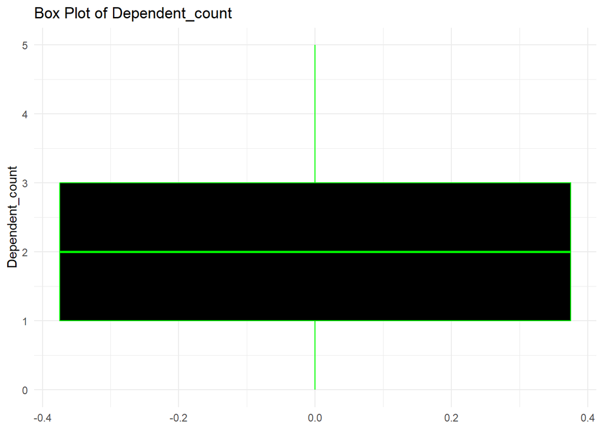

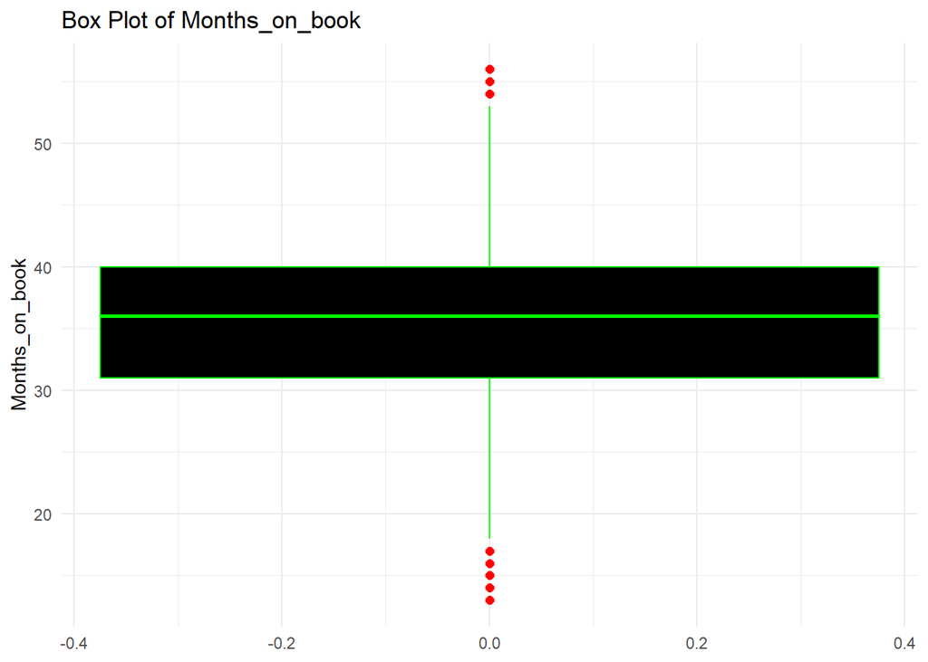

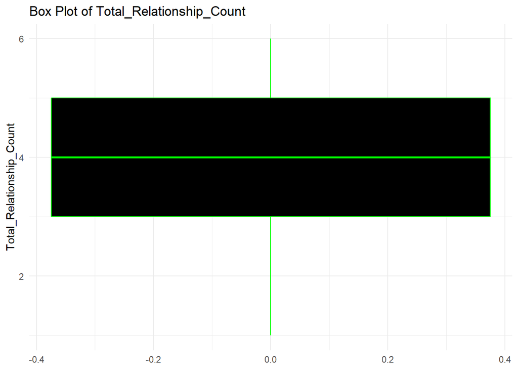

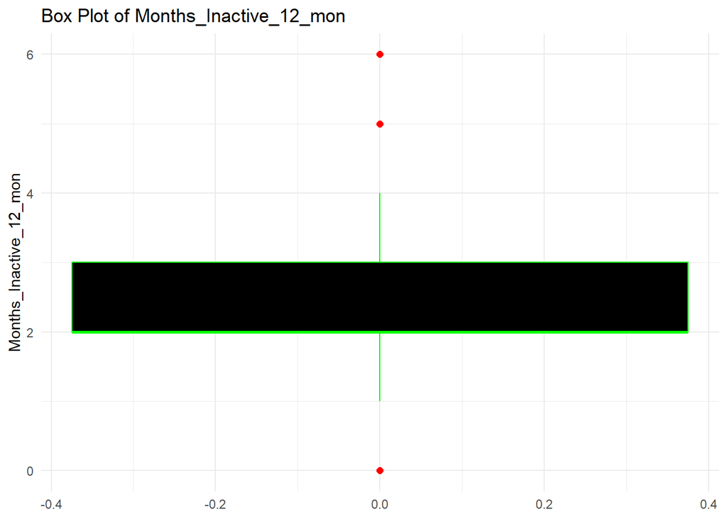

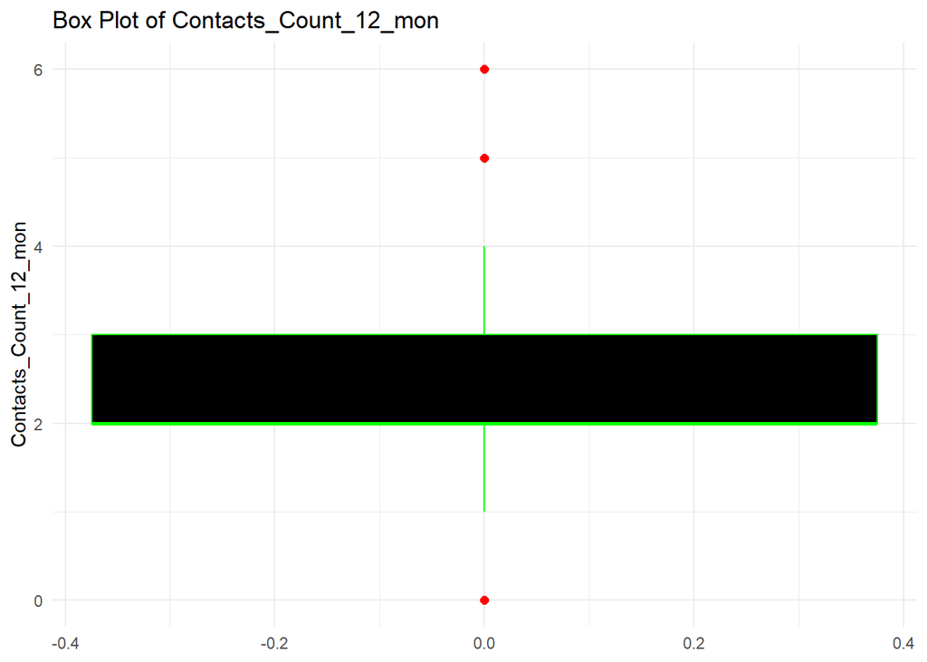

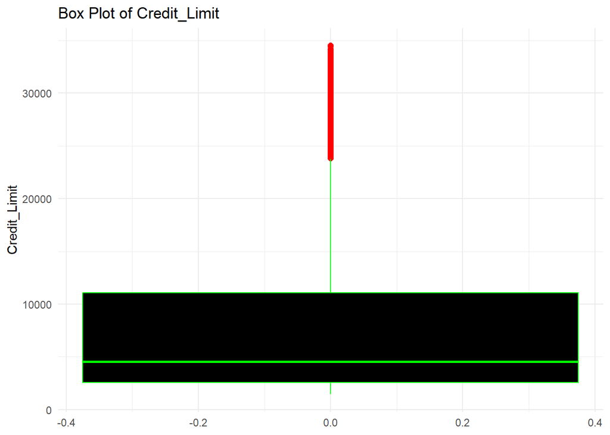

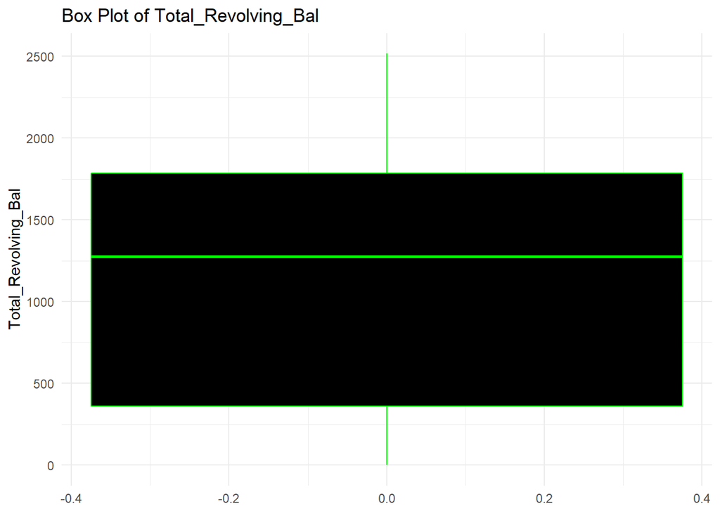

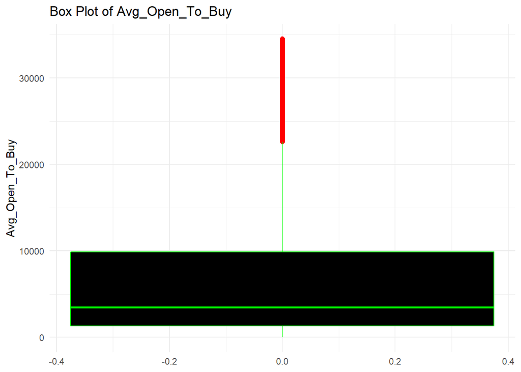

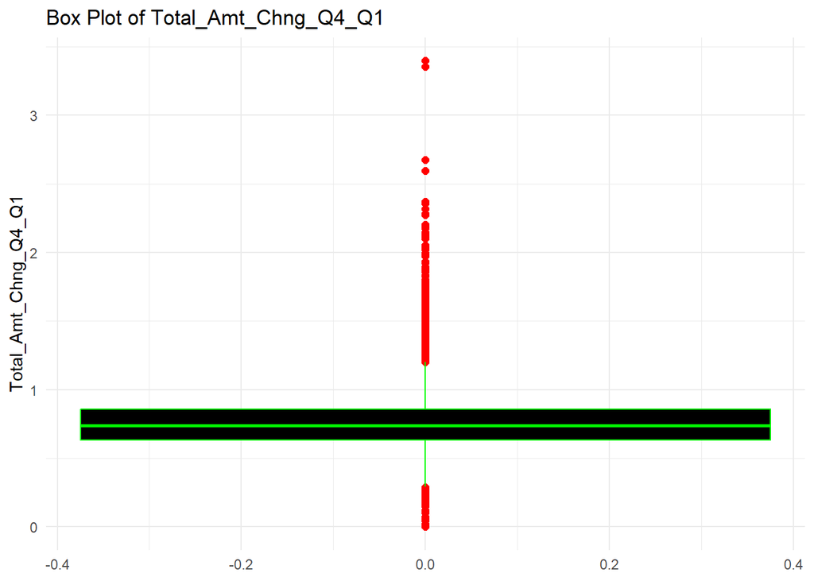

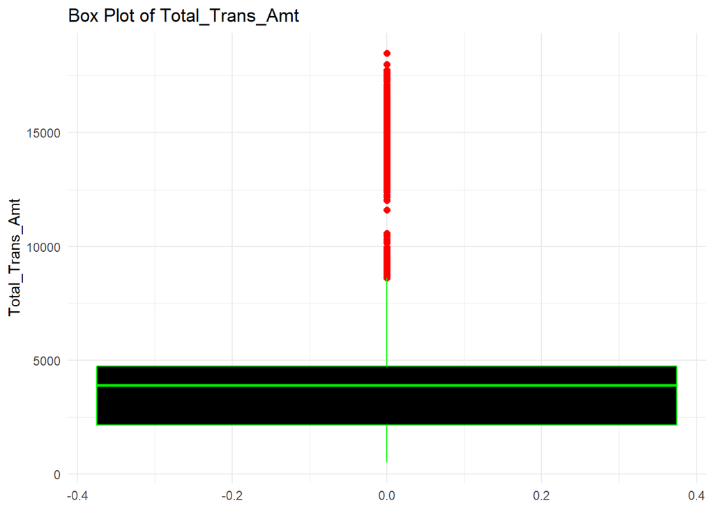

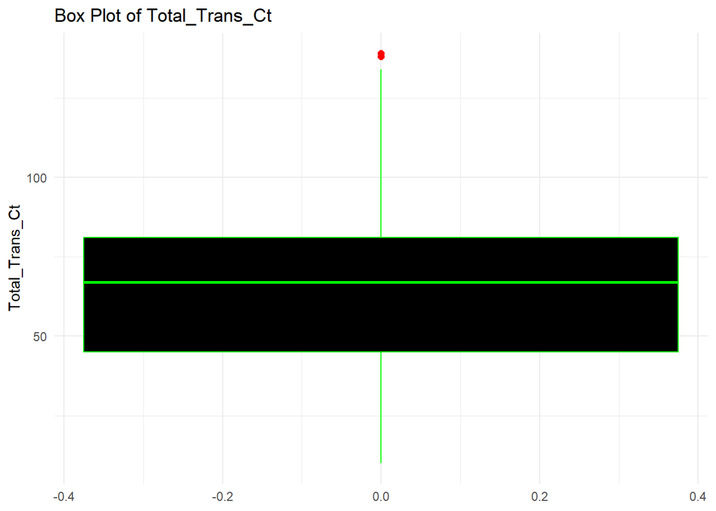

[2 more figures not shown]

```r
for(i in 1:length(variable_columns)) {
  p <- ggplot(credit_card_final_without_unknown, aes(y = credit_card_final_without_unknown[[variable_columns[i]]])) +
    geom_boxplot(fill = 'black', color = 'green', outlier.color = "red", outlier.size = 2) +
    labs(title = paste("Box Plot of", col_names[i]), y = col_names[i]) +
    theme_minimal()

  print(p)
}
```